# Single cell RNA-seq clustering

## Initialize workspace

Load required packages and functions.

```r
#### Install packages ####
if (! require(Rtsne)) {
  install.packages("Rtsne")
  require(Rtsne)
}
if (! require(Rphenograph)) {
  if (! require(devtools)) {
    install.packages("devtools")
  }
  devtools::install_github("JinmiaoChenLab/Rphenograph")
  require(Rphenograph)
}
#### Load functions ####
source(file = "fCalcBrokenStick.R")
source(file = "fCountMarkerGenes.R")
#### Set color palette ####
pal1 <- c("#d77a7f", "#8eda48", "#7340cd", "#d6c847", "#ce4cc5", "#64db8e",
          "#432876", "#509140", "#7171cd", "#d1863a", "#79acd9", "#d24530",
          "#6dc7b7", "#d23e70", "#c6d394", "#8d3870", "#827f38", "#cd90cb",
          "#3a4e32", "#c9c5c6", "#3e263b", "#ae8875", "#556983", "#753627")
palette(pal1)
# Set random number seed
set.seed(123)
```

## Load data

This data set includes 300 nuclei, 250 NeuN+ (neuronal) and 50 NeuN- (non-neuronal), dissected from Layer 5 of human neocortex (middle temporal gyrus). The full data set (15,928 nuclei) can be downloaded from the Allen Institute Cell Types Database: http://celltypes.brain-map.org/download.

## Subset data

- Keep nuclei with sufficient gene expression
- Normalize and log-transform expression data

```r
# Keep cells with at least M genes detected
min.genes <- 1000
keep.samp <- which(apply(expr, 2, function(x) sum(x > 0)) > min.genes)
# Keep genes with some variability
keep.genes <- which(apply(expr[, keep.samp], 1, sd) > 0)
# Subset and log-transform counts per million
expr.cnt <- expr[keep.genes, keep.samp]
expr.cpm <- sweep(expr.cnt, 2, colSums(expr.cnt), "/") * 1e6
expr.log <- log2(expr.cpm + 1)
meta.subset <- droplevels(meta[keep.samp, ])
rownames(meta.subset) <- colnames(expr.cnt)
genes.subset <- droplevels(genes[keep.genes, ])
```

## Select variable genes

Select significantly variable genes across nuclei based on expression dispersion.

```r
expr.mean <- apply(expr.cpm, 1, mean)
expr.mean.bin <- cut(expr.mean, breaks = 10^seq(-5, 5, 0.1), include.lowest = TRUE)
expr.sd <- apply(expr.cpm, 1, sd)
expr.cv <- expr.sd / expr.mean
expr.cv.z.list <- tapply(expr.cv, expr.mean.bin, scale)
expr.cv.z <- do.call("rbind", expr.cv.z.list)
expr.cv.z <- expr.cv.z[match(names(expr.mean), rownames(expr.cv.z)), 1]
expr.cv.z[expr.cv.z > 8] <- 8
# Select z-score threshold for variable genes
z.thresh <- 2
top.var.genes <- which(expr.cv.z > z.thresh & expr.mean > 0.1)
par(mfrow = c(1, 2))
plot(expr.mean, expr.cv, cex = 0.5, log = "xy",
     xlab = "Average expression",
     ylab = "Coefficient of variation (CV)",
     main = paste(length(top.var.genes), "variable genes"))
points(expr.mean[top.var.genes], expr.cv[top.var.genes], col = "orange", pch = 19)
```

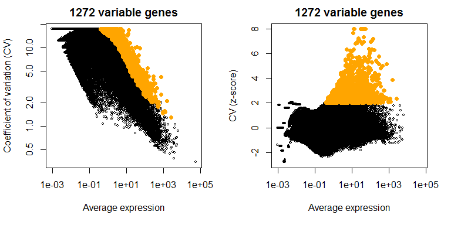

```r
plot(expr.mean, expr.cv.z, cex = 0.5, log = "x",
     xlab = "Average expression",
     ylab = "CV (z-score)",
     main = paste(length(top.var.genes), "variable genes"))
points(expr.mean[top.var.genes], expr.cv.z[top.var.genes], col = "orange", pch = 19)
```

## Reduce dimensionality

Run principal components analysis (PCA) to find low-dimensional representation of expression patterns.

```r
# Center and z-score genes across samples
expr.scaled <- scale(expr.cpm)
# Calculate PCA using variable genes
pca1 <- prcomp(expr.scaled[top.var.genes, ])
```

## Select principal components

Identify principal components that explain a significant proportion of expression variance compared to chance.

```r
# Find PCs with more variance explained than broken stick distribution
brstick1 <- CalcBrokenStick(pca1$sdev^2)
max.pcs <- 20
sig.pcs <- NULL
for (i in 1:max.pcs) {
  var.pct <- brstick1[i, "var_pct"]
  var.thresh <- brstick1[i, "bstick_thresh"]
  if (var.pct > var.thresh) {
    sig.pcs <- c(sig.pcs, brstick1[i, "pc"])
  } else {
    break
  }
}
# Select PCs to retain for further analysis
keep.pcs <- sig.pcs
pca.var <- summary(pca1)$importance[1, ]^2
plot(pca.var[1:max.pcs], type = "b", xlab = "PC", ylab = "Explained variance")
abline(v = max(sig.pcs), col = "light blue")
```

```r
text(x = max(sig.pcs), y = 0.9 * max(pca.var), labels = "# significant PCs", pos = 2)
abline(v = max(keep.pcs), col = "blue")
```

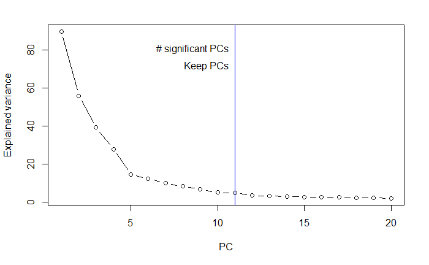

```r
text(x = max(keep.pcs), y = 0.8 * max(pca.var), labels = "Keep PCs", pos = 2)
```

```r
expr.pcs <- pca1$rotation[, keep.pcs]
```

## Cluster cells

### K-means

Try a range of cluster numbers.

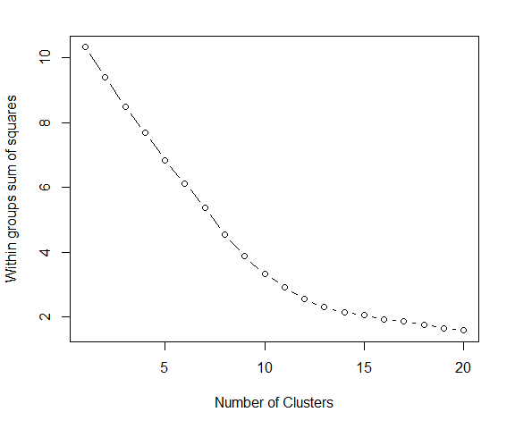

```r
# K-means clustering
km.list <- list()
within.ss <- NULL
for (i in 1:20) {
  km1 <- kmeans(expr.pcs, centers = i, iter.max = 100, nstart = 100)
  km.list[[i]] <- km1
  within.ss[i] <- km1$tot.withinss
}
plot(1:20, within.ss, type="b",
     xlab="Number of Clusters", ylab="Within groups sum of squares")
# tSNE dimensionality reduction for cluster visualization
tsne1 <- Rtsne(expr.pcs, perplexity = 20)$Y
par(mfrow = c(3, 4), mar = c(1, 1, 4, 1))
```

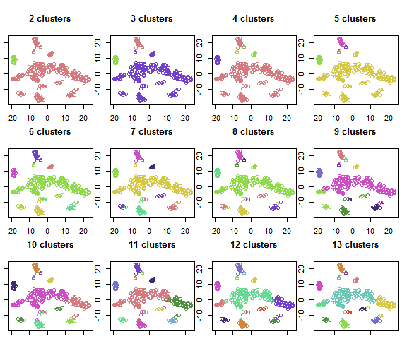

```r
for (i in 2:13) {
  cl.lab <- km.list[[i]]$cluster
  plot(tsne1, col = cl.lab, xlab = "tSNE1", ylab = "tSNE2", main = paste(i, "clusters"))
  # plot(expr.pcs[, 1:2], col = cl.lab, main = paste(i, "clusters"))
}
```

### Graph based clustering

- K nearest neighbors in PCA space
- Jaccard similarity to better separate weakly joined clusters
- Louvain community detection to identify clusters maximizing network modularity

```r
# Graph-based clustering (Jaccard/Louvain)
nn.num <- 15  # Number of nearest cells to compare in building graph
graph.cl <- Rphenograph(expr.pcs, k = nn.num)
```

```
Run Rphenograph starts:
  -Input data of 300 rows and 11 columns
  -k is set to 15
```

```
  Finding nearest neighbors...DONE ~ 0 s
  Compute jaccard coefficient between nearest-neighbor sets...DONE ~ 0.01 s
  Build undirected graph from the weighted links...DONE ~ 0.09 s
  Run louvain clustering on the graph ...DONE ~ 0.03 s
```

```
Run Rphenograph DONE, totally takes 0.129999999999995s.
```

```
  Return a community class
  -Modularity value: 0.8331473
  -Number of clusters: 12
```

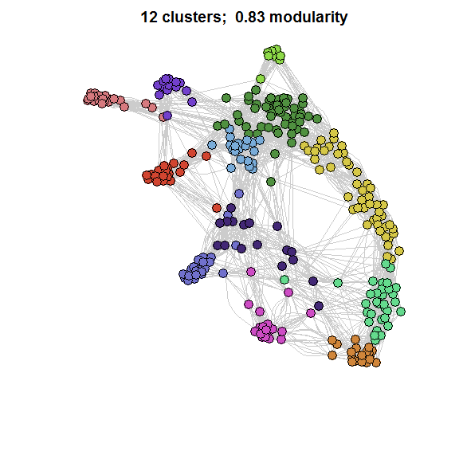

```r
plot.lab <- paste(length(unique(membership(graph.cl[[2]]))), "clusters; ",
                  round(modularity(graph.cl[[2]]), 2), "modularity")
plot(graph.cl[[1]], vertex.size = 6, vertex.label = NA, edge.color = "grey80",
     vertex.color = pal1[membership(graph.cl[[2]])], main = plot.lab)
```

## Select clustering

Select clusters for final curation and visualization.

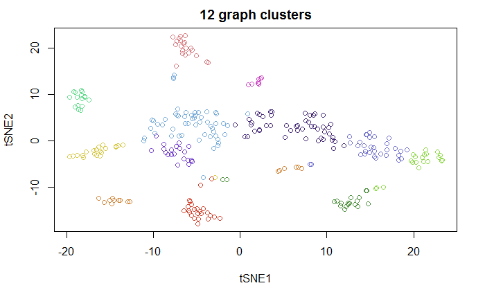

```r
# Store clustering results
cell.cl <- list()
n.clus <- 12  # Number of kmeans clusters
cell.cl[["kmeans"]] <- km.list[[n.clus]]$cluster
cell.cl[["graph"]] <- membership(graph.cl[[2]])
cell.cl[["neun"]] <- meta.subset$facs_population_plan
# Select clusters
select.cl <- "graph"
meta.subset$cluster <- as.character(cell.cl[[select.cl]])
plot(tsne1, col = as.factor(meta.subset$cluster), xlab = "tSNE1", ylab = "tSNE2",
      main = paste(length(unique(meta.subset$cluster)), select.cl, "clusters"))
```

```r
# pairs(expr.pcs[, 1:min(4, max(keep.pcs))], col = meta.subset$cluster,
#       main = paste(length(unique(meta.subset$cluster)), "clusters"))
```

## Curate clusters

Merge clusters that are too small or lack marker genes.

```r
# Cell type criteria
p.expr.thresh <- 1  # Marker gene: Min expression for detection above noise
target.prop <- 0.5  # Marker gene: Min detection (proportion of cells) in target cluster
other.prop <- 0.1  # Marker gene: Max detection in other clusters
min.markers <- 1  # Min number of marker genes
min.cl.size <- 3  # Min number of cells
# Iteratively merge clusters based on above criteria
meta.subset$cluster_curated <- meta.subset$cluster
merge.cl <- TRUE
while (merge.cl) {
  cl.marker.cnt <- CountMarkerGenes(expr.cpm, meta.subset$cluster_curated,
                                    expr.thresh = p.expr.thresh,
                                    cl1.prop = target.prop, cl2.prop = other.prop)
  print(head(cl.marker.cnt, 3))
  cl.tomerge <- which(cl.marker.cnt$min.size < min.cl.size |
                        cl.marker.cnt$min.dex.cnt < min.markers)

  if (length(cl.tomerge) > 0) {
    for (idx1 in cl.tomerge) {
      cl.from <- cl.marker.cnt$cl2[idx1]
      cl.to <- cl.marker.cnt$cl1[idx1]
      meta.subset$cluster_curated[meta.subset$cluster_curated == cl.from] <- cl.to
    }
  } else {
    merge.cl <- FALSE
  }
}
```

|  | cl1 | cl2 | min.size | min.dex.cnt |
| --- | --- | --- | --- | --- |
| 25 | 11 | 4 | 20 | 0 |
| 53 | 4 | 6 | 32 | 0 |
| 55 | 4 | 8 | 48 | 0 |

|  | cl1 | cl2 | min.size | min.dex.cnt |
| --- | --- | --- | --- | --- |
| 21 | 11 | 4 | 68 | 0 |
| 14 | 10 | 4 | 20 | 3 |
| 10 | 10 | 11 | 20 | 5 |

|  | cl1 | cl2 | min.size | min.dex.cnt |
| --- | --- | --- | --- | --- |
| 9 | 10 | 11 | 20 | 4 |
| 4 | 1 | 2 | 8 | 7 |
| 13 | 10 | 5 | 19 | 8 |

## Visualize clusters

Plot relationships between initial and curated clusters.

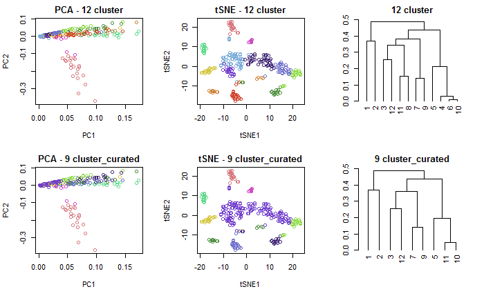

```r
par(mfrow = c(2, 3))
for (clus1 in c("cluster", "cluster_curated")) {
  plot.color <- pal1[as.factor(meta.subset[, clus1])]
  plot(expr.pcs[, 1:2], col = plot.color,
      main = paste("PCA -", length(unique(meta.subset[, clus1])), clus1))
  plot(tsne1, col = plot.color, xlab = "tSNE1", ylab = "tSNE2",
      main = paste("tSNE -", length(unique(meta.subset[, clus1])), clus1))
  cl.expr <- t(apply(expr.cpm[top.var.genes, ], 1,
                     function(x) tapply(x, meta.subset[, clus1], mean)))
  cl.dist <- as.dist((1 - cor(cl.expr)) / 2)
  cl.dend <- as.dendrogram(hclust(cl.dist))

  # Reorder dendrogram to match cluster position along first tSNE coordinate
  cl.coord <- tapply(tsne1[, 1], meta.subset[, clus1], mean)
  cl.dend <- reorder(cl.dend, cl.coord, agglo.FUN = "mean")
  plot(cl.dend, main = paste(length(unique(meta.subset[, clus1])), clus1))
}
```

## Further analyses

1. Cluster with different parameters
   - Adjust threshold for variable genes
   - Select more/fewer principal components
   - Vary number of nearest neighbors for graph based clustering
   - Change criteria for merging cell types
2. Compare membership of different clustering results
3. Try splitting the largest cluster by rerunning clustering using only those nuclei
4. Identify and plot expression of cluster markers
5. Download and cluster other data sets

## Resources

1. RNA-seq data sets
   - Allen Institute Cell Types Database http://celltypes.brain-map.org/download
   - Single Cell Portal (Broad Institute) https://portals.broadinstitute.org/single_cell
   - SCAP-T https://www.scap-t.org/content/data-portal
   - NCBI GEO DataSets https://www.ncbi.nlm.nih.gov/gds
2. Analysis tools
   - Cell sampling http://satijalab.org/howmanycells
   - BASiCS https://github.com/catavallejos/BASiCS
   - RUVSeq http://bioconductor.org/packages/release/bioc/html/RUVSeq.html
   - DESeq2 https://bioconductor.org/packages/release/bioc/html/DESeq2.html
   - scde http://hms-dbmi.github.io/scde/
   - WGCNA https://labs.genetics.ucla.edu/horvath/CoexpressionNetwork/Rpackages/WGCNA/
   - tSNE https://lvdmaaten.github.io/tsne/
   - ToppGene GO enrichment https://toppgene.cchmc.org/enrichment.jsp
3. Clustering tools
   - DBSCAN https://cran.r-project.org/web/packages/dbscan/
   - Pagoda https://github.com/hms-dbmi/pagoda2
   - Seurat http://satijalab.org/seurat/
   - BackSpin https://github.com/linnarsson-lab/BackSPIN
   - PhenoGraph https://www.c2b2.columbia.edu/danapeerlab/html/phenograph.html
   - SIMLR https://github.com/BatzoglouLabSU/SIMLR